# **House For Sale**

Kanishka Goyal

## Background

**Ames** is a small city in the state of *Iowa* in the *United States*. The data set used in this analysis was originally compiled by **Professor Dean De Cock** in **2011**. It contains observations on housing sales in Ames between the years **2006 and 2010** [1]. There are 81 different features describing each house’s size, quality, area, age, and other miscellaneous attributes. There is one more variable *SalePrice*, totaling the variable count to 82. The data set has a total of 2919 observations which has been split into Train and Test data set. A detailed description of each variable can be accessed through [**Ames data set decription**](https://www.kaggle.com/c/house-prices-advanced-regression-techniques/data?select=data_description.txt)

## Problem Identification

- **Problem 1** - Analyze if age of the House has an impact on sale price across different types of foundation.
- **Problem 2** - Analyze whether Basement/ Garage has any effect on sale price.
- **Problem 3** - How has the Average Sale Price changed from year 2006 to 2010 across different neighborhoods?
- **Problem 4** - Are quality/ condition features affecting sale price?
- **Problem 5** - Does the sale price fluctuate across seasons of the year?
- **Problem 6** - Analyze if Lot size, or various other area measurements make an impact on sale price.
- **Problem 7** - Analyze other key features to find what best predicts the sale price.
- **Problem 8** - How are Number of Sales distributed among neighborhoods/ Building type across time?
- **Problem 9** - Develop models to predict Sale Price based on the analysis performed in previous steps.
- **Problem 10** - Evaluate the models created and select the fit that best predicts the sales price.

## Data preprocessing

Data pre-processing is a very important aspect of a data science project and accounts for almost half of the work in many cases. It helps to manage missing data, detect outliers, change variable names etc.. In data pre-processing the data is cleaned in a series of steps to make it easily and readily available for later stages of the project.

```r
# Loading data sets into working directory--------------------------------------

train_data <- read.csv("train.csv")
test_data <- read.csv("test.csv")

# Setting my standard theme-----------------------------------------------------

my_theme <- theme(
  panel.background = element_rect( fill = "ivory2" , color ="gray"),
  plot.background = element_rect( color = "black"),
  plot.title = element_text(size = 14, face = "bold", hjust = 0.5),
  axis.title.x = element_text(size = 12, hjust = 0.5),
  axis.title.y = element_text(size = 12, hjust = 0.5))
```

##### **1. Missing data management** -

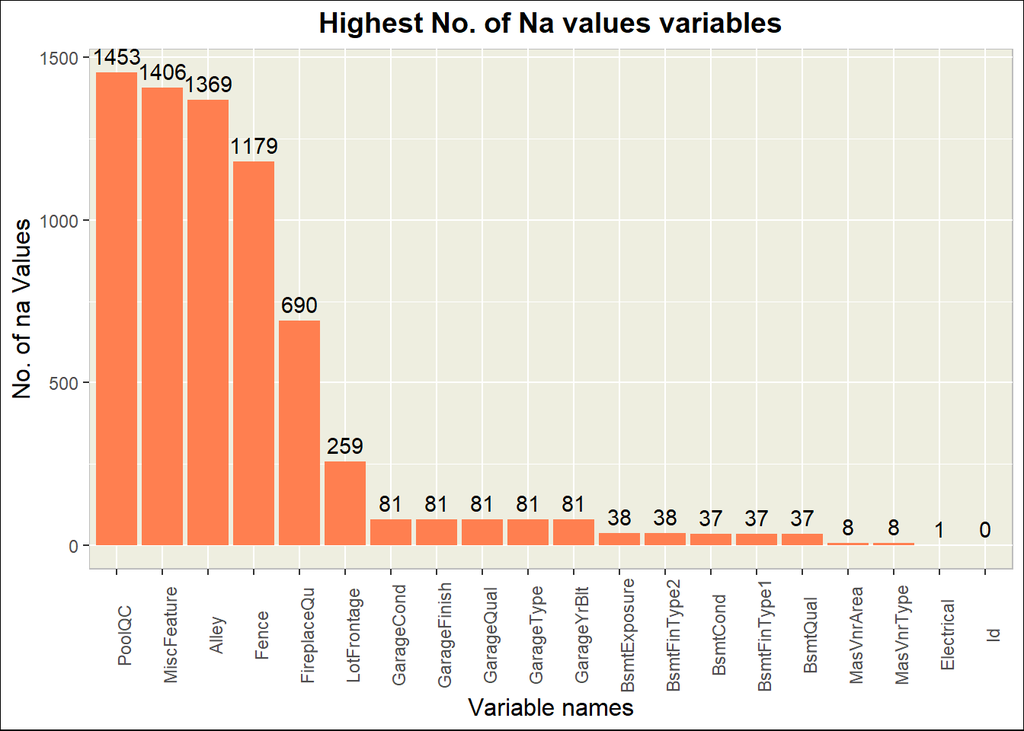

**a.** The first step is to remove the variables that are 100% empty.

```
## [1] "There are no columns that are all empty"
```

**b.** On analysing the variable description, which can be found [**here**](https://www.kaggle.com/c/house-prices-advanced-regression-techniques/data?select=data_description.txt), I found a different aspect of missing values in this data. It’s true that, there are a lot of categorical variables with *NA* values, but in many of these variables, *NA* does not represent missing data, it rather represents that, that specific feature/ facility was missing in the house. For instance in variables like Basement, Fireplace, Garage, Pool, Fence, Alley etc., *NA* stand for the feature not available. So, for all these categorical variables where NA means missing facility, I replaced the *NA* with a character string *“None”*.

```r
# Replacing NA with "None" for all those variables where NA stand for missing
# feature rather than missing information --------------------------------------

na_correction <- c("BsmtExposure","BsmtFinType1", "BsmtFinType2", "Alley",
                   "GarageType", "GarageFinish",  "Fence" ,  "MiscFeature",
                   "PoolQC", "FireplaceQu", "GarageQual" , "GarageCond",
                   "BsmtQual" , "BsmtCond")

for(i in 1:length(na_correction)){
  for(j in 1:nrow(train_data)){
    if(is.na(train_data[j,na_correction[i]])){
      train_data[j,na_correction[i]] <- "None"
    }
  }
}
```

**c.** For the other variables, where *NA*, actually meant missing information, Na’s were managed as follows-

```r
# Lot Frontage is Linear feet of street connected to property
# Replace NA values with median grouped on type of street

train_data <- train_data %>%
  group_by(Street) %>%
  mutate( LotFrontage = ifelse(is.na(LotFrontage),
                               median(LotFrontage, na.rm = TRUE),
                               LotFrontage))
```

##### **2. Wrangling Quality variables** -

There are many categorical variables in data who has their values in the form of ranks ranging from Poor -> Excellent.

1. Po Poor
2. Fa Fair
3. TA Average/Typical
4. Gd Good
5. Ex Excellent

For an effective analysis of these variables, I changed their values from Character (Po, Fa, TA, Gd, Ex) to Numeric (1, 2, 3, 4, 5). By doing this, these variables can be used to find correlations or create scatter plot matrices with sale price variable.

```r
# Changing Quality & Condition variables----------------------------------------

var_list <- c(
  "ExterQual", "ExterCond" , "BsmtQual" , "KitchenQual" ,
  "FireplaceQu" , "GarageQual" , "GarageCond"
)

var_index_list <- c(
  28,29,31,54,58,64,65
)

for( i in var_index_list){
  for(j in 1:nrow(train_data)){
      if(train_data[j,i] == "Ex"){
        train_data[j,i] <- "5" }
      else if(train_data[j,i] == "Gd"){
        train_data[j,i] <- "4" }
      else if(train_data[j,i] == "TA"){
        train_data[j,i] <- "3" }
      else if(train_data[j,i] == "Fa"){
        train_data[j,i] <- "2" }
      else if(train_data[j,i] == "Po"){
        train_data[j,i] <- "1" }
      else{
      train_data[j,i] <- "0" }
  }
}

for(i in var_index_list){
  train_data[[i]]  <- as.numeric(train_data[[i]])
}
```

##### 3. **Sale Price/ log_Sale price** -

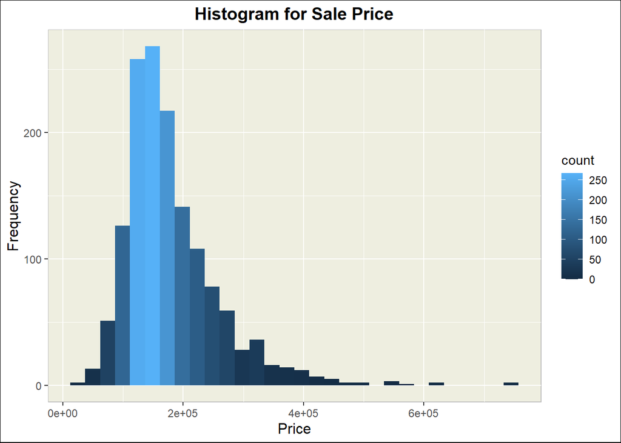

On plotting a histogram of Sale Price, it was seen that, it has a big stretch in the right and is extremely skewed with few outliers. So, to improve the target variable, mutated a new variable log_price, which takes the log of e for all the sale price values.

```r
train_data <- train_data %>%
  mutate(log_price = log(SalePrice))
```

## Exploratory data analysis

EDA provides data visualization methodologies which help to understand and summarize a data set without prior assumptions. It is crucial for gaining insight into data. Analysis Problems identified at the start of the project will be discussed here-

#### **Problem 1 - Analyze if age of the House has an impact on sales price across different types of foundation.**

##### **Sale Price vs. Age across Foundations -**

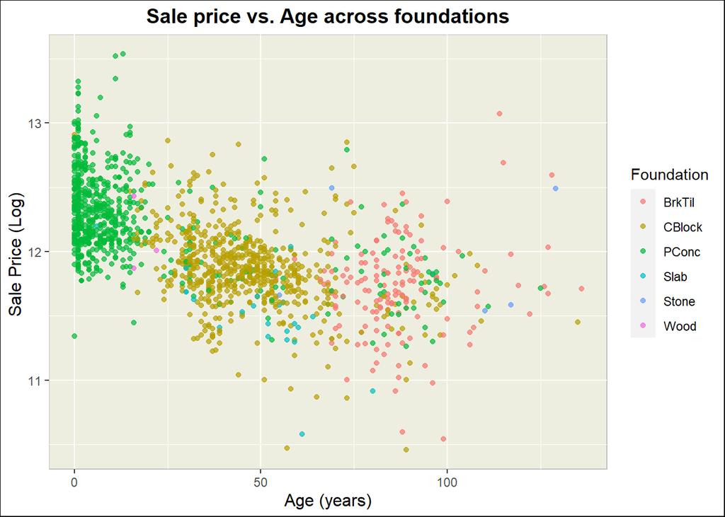

```r
train_data$Age <- train_data$YrSold - train_data$YearBuilt

train_data %>%
  ggplot(aes(x = Age, y = log_price, color = Foundation)) +
  geom_point(alpha = 0.7) +
  labs(
    x = "Age (years)",
    y = "Sale Price (Log) ",
    title = "Sale price vs. Age across foundations"
  ) +
  my_theme
```

#### **Problem 2 - Analyze whether Basement/ Garage has any effect on sale price.**

##### **1. Analyze if Basement has an effect-**

```r
# Correlation plot on numeric variables related to basement

ggcorr(train_data[,c(31,35,37,38,39,82)], label = T, name = "rho")
```

[output not shown]

```r
# Total sq ft. area of basement and Basement quality seems to impact
# sale price.

# Plotting Total Sq. ft. area of basement

train_data %>%
  ggplot(aes(x = TotalBsmtSF, y = log_price)) +
  geom_point(alpha = 0.7) +
  geom_smooth() +
  labs(
    x = " Total Basement area (sq. ft.)",
    y = " Sale Price (Log)",
    title = "Sale price vs Basement area"
  ) +
  my_theme
# There is one extreme outlier in the data which is tampering the trend line.
# Also, the variable which do not have a basement hinder in the analysis.

# Removing outlier

train_data <- train_data[-(which.max(train_data$TotalBsmtSF)),]
```

[output not shown]

##### **1. Sale Price vs. Total Basement area**

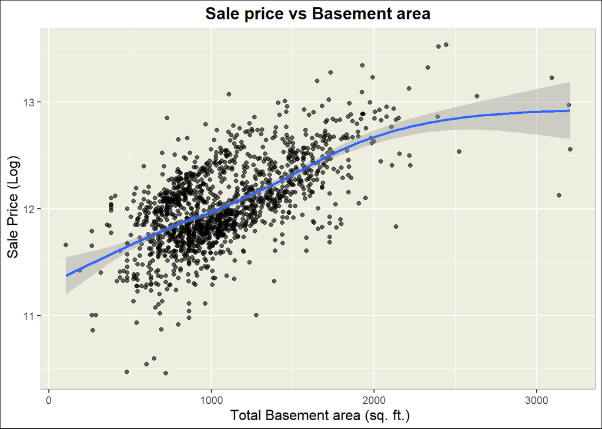

```r
# Plotting again without considering the data that does not have a basement

train_data %>%
  filter(TotalBsmtSF > 0) %>%
  ggplot(aes(x = TotalBsmtSF, y = log_price)) +
  geom_point(alpha = 0.6) +
  geom_smooth() +
  labs(
    x = " Total Basement area (sq. ft.)",
    y = " Sale Price (Log)",
    title = "Sale price vs Basement area"
  ) +
  my_theme
```

The plot above depicts that there is a moderate relation between Basement area and Sale price. The relation is near linear. Even after removing the extreme **outliers**, the remaining ones tend to bend the curve line towards itself.

##### **2. Sale Price vs. Basement Quality**

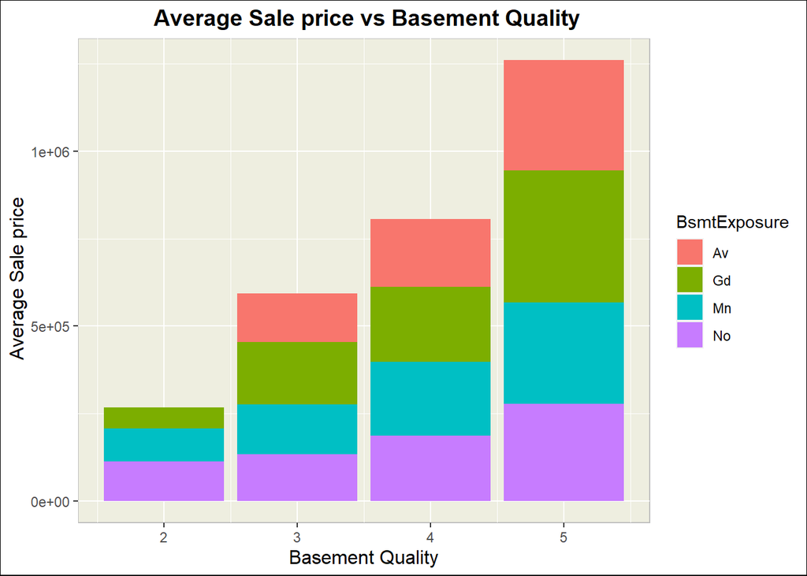

The stack Bar plot above depicts that there is a linear relation between Basement Quality and Sale price. The relation is moderate. It also, shows that there is no major relationship between Basement Expoure and Basment Quality as there is equal distribution among all the bars.

##### 3. **Sale Price vs. Basement Exposure**

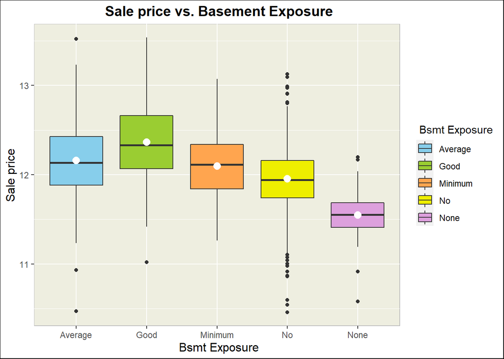

There is a relation between Sale Price and Basement Exposure, as the Exposure increases, Sale price also increases. But, the relation is not very strong as the boxes are not very far away from one another.

##### **2. Analyze if Garage has an effect-**

```r
# Correlation plot on numeric variables related to GARAGE-----------------------

ggcorr(train_data[,c(60,62,63,64,65,82)], label = T, name = "rho")
```

[output not shown]

```r
# Garage area, Garage Cars has some good correlation with sale price.
# Garage year built has some relation too with a correlation of 0.5
```

##### **1. Sale price vs. Garage Area in relation to Garage Age**

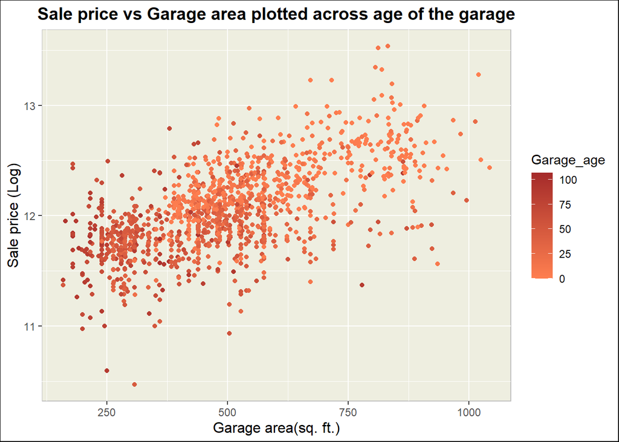

```r
# Plot Sale price vs Garage Area plotted across age of garage-------------------

train_data %>%
  filter( GarageArea > 0 , GarageArea < 1050) %>%
  mutate(Garage_age = YrSold - GarageYrBlt) %>%
  ggplot(aes(x = GarageArea, y = log_price, color = Garage_age)) +
  geom_jitter() +
  scale_color_gradient(low ="coral", high = "brown") +
  labs(
    x = "Garage area(sq. ft.)",
    y = "Sale price (Log)",
    title = "Sale price vs Garage area plotted across age of the garage"
  ) +
  my_theme
```

Similar, negative trend between Garage Age and Price can be observed. Additionally, a moderate relation between Garage Area and Sale price.

##### **2. Sale price vs. Garage Type**

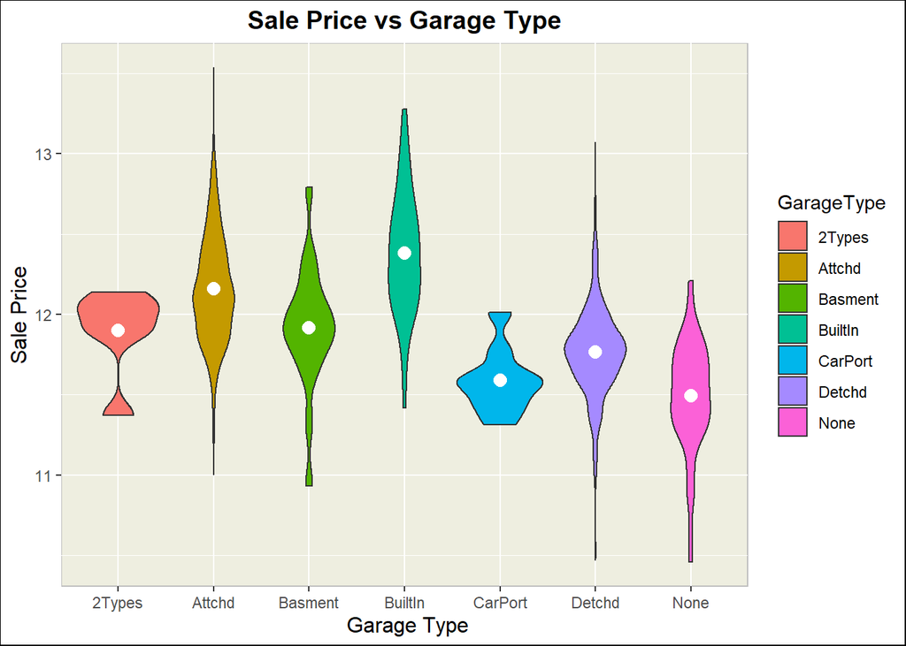

The type of Garage does not seem to hold any big impact on Sale price as there is a very less variability and a huge overlap between all the categories.

#### **Problem 3 - How has the Average Sale Price changed from year 2006 to 2010 across different neighborhoods?**

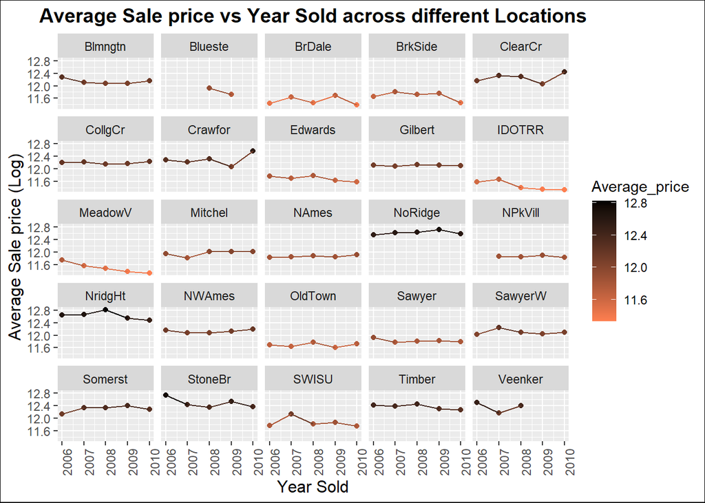

```r
train_data %>%
  group_by(YrSold, Neighborhood) %>%
  summarize(Average_price = median(log_price)) %>%
  ggplot(aes(x = YrSold, y = Average_price, color = Average_price)) +
  geom_point()  +
  geom_line() +
  scale_color_gradient(low ="coral", high = "black") +
  facet_wrap(~ Neighborhood) +
  labs(
    x = "Year Sold",
    y = " Average Sale price (Log)",
    title = "Average Sale price vs Year Sold across different Locations"
  ) +
  theme(axis.text.x = element_text(angle = 90),
        plot.background = element_rect( color = "black"),
        plot.title = element_text(size = 14, face = "bold", hjust = 0.5),
        axis.title.x = element_text(size = 12, hjust = 0.5),
        axis.title.y = element_text(size = 12, hjust = 0.5))
```

As in the plot shown above, most of the neighborhoods did not show any major hike in Sale price throughout all years but some surubs such as *Crawfor*, *ClearCr* showed an increase in 2010. There are a few neighborhoods showing changes every year. This plot also shows that a few neighborhoods such as *NoRidge* , *NridgeHt*, *StoneBr* has huge Sale prices on average as compared to other neighborhoods.

#### **Problem 4 - How are quality/ condition features effecting sale price?**

##### **Plot of all the four major qualities impacting Sale Price -**

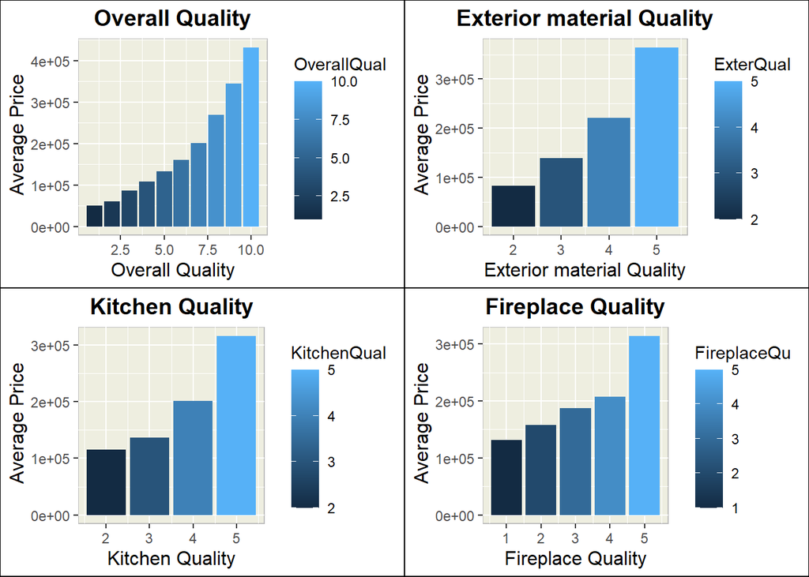

The plot here clearly depicts that Quality variables make a huge impact on Sale Price. In all the four quality variables shown above there is a linear-> exponential increase in Sale price of the property. I have made the plots only for the data that has that facility. The data which lacked that particular facility was omitted while plotting.

#### **Problem 5 - Does the sale price fluctuate across seasons of the year?**

To analyze, if season has any impact on No. of sales in Ames. Mutated a Season_sold variable that takes data from Month Sold and assigns the month accordingly. In Ames, Iowa Summer exists from June to August, Autumn from September to November, Winter from December to February, and Spring from the month of March to May.[2]

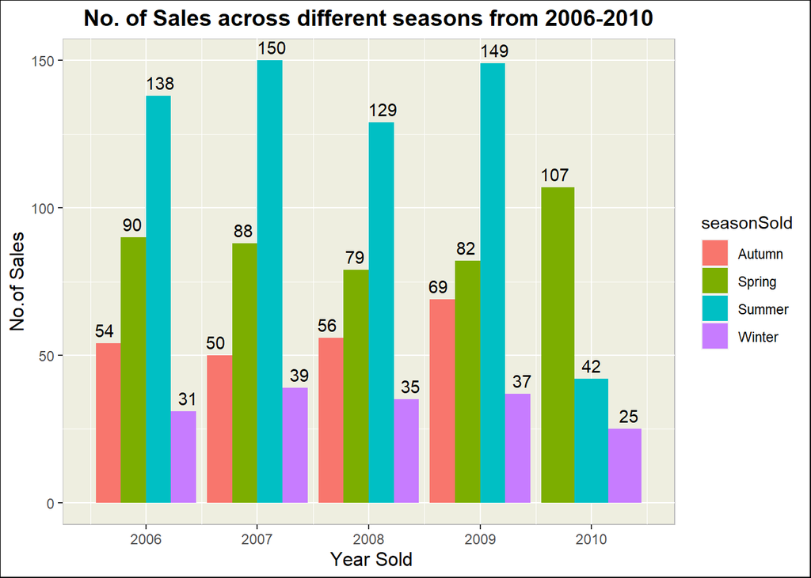

#### **Problem 6 - Analyze if Lot size, or various other area measurements make an impact on sale price.**

For analyzing the correlation between numeric variables, such as Area, Lot size and other area measurements, the variables of interest have been divided into two sets and both include Log Price.

##### **Scatter Plot matrix for Living and First floor area and Sale price-**

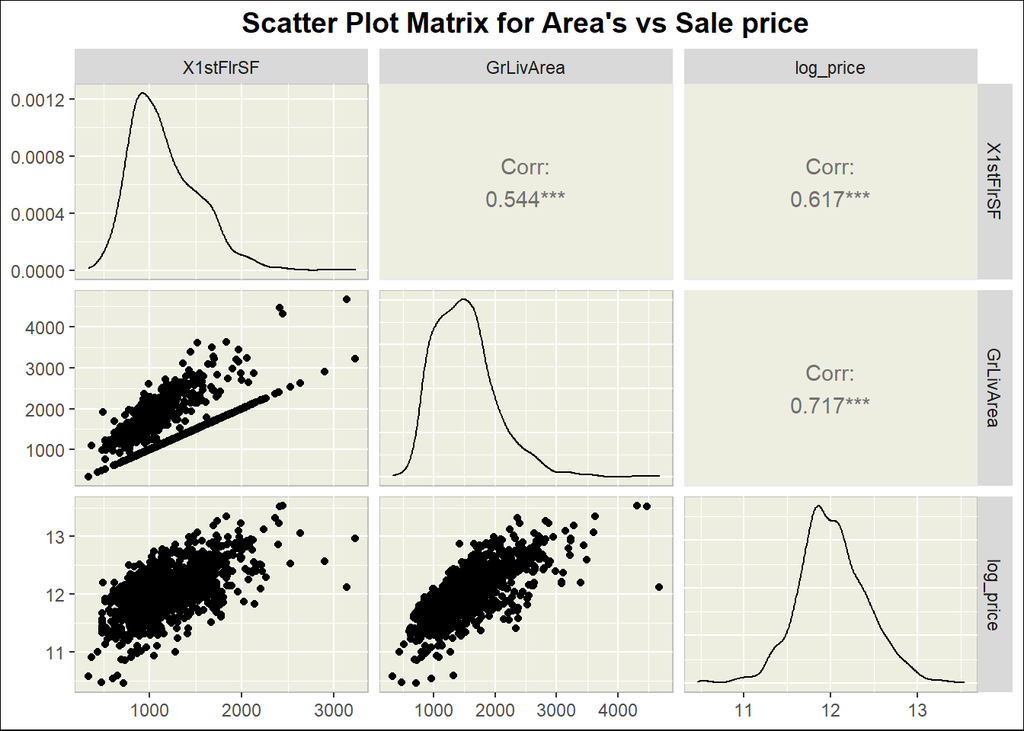

##### **Sale Price vs. living area and Total number of rooms -**

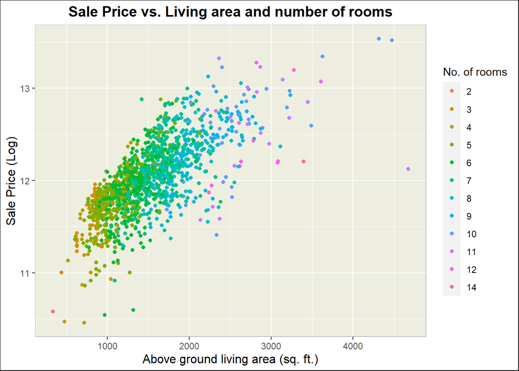

The plot above shows that there is a moderate - > strong correlation between Sale price and Living area. It’s a near linear trend with a few outliers. There is also a good relation between Living area and No. of rooms, as the houses with large Living area have more number of rooms with a few exceptions. A few *Value-outliers* can be seen in the plot.

#### **Problem 7 - Analyze other key features to find what best predicts the sale price.**

##### **Sale price vs. Neighborhood -**

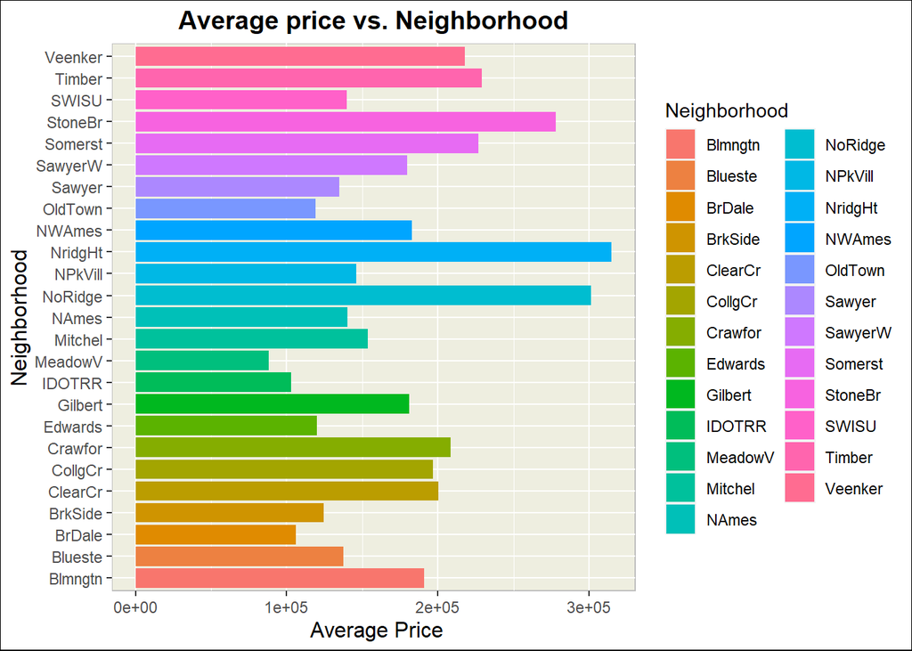

High average price for neighborhoods like NridgHt, NoRidge, StoneBr. The variation shows that Neighborhood is a good factor to depict Sale Price.

##### **Sale price vs. Foundation -**

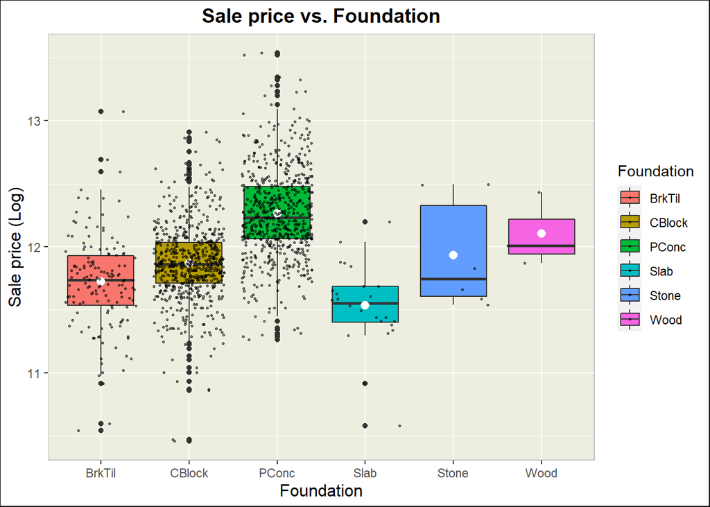

#### **Problem 8 - How are Number of Sales distributed among neighborhoods/ Building type across time?**

##### **No. of Sales vs. Neighborhood across time** -

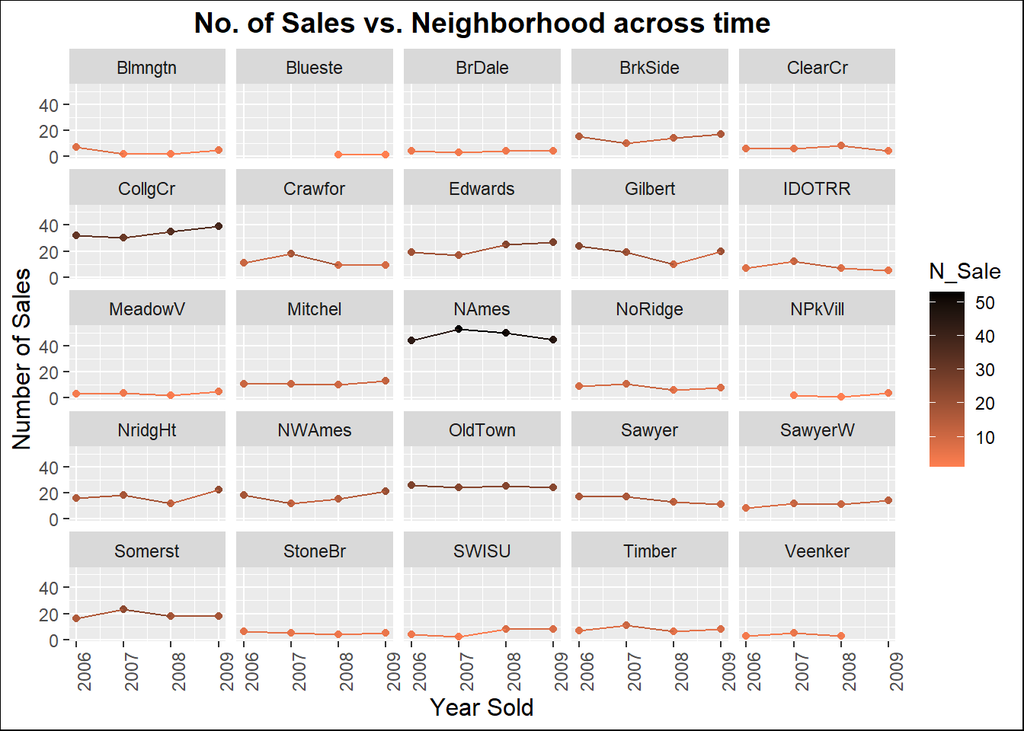

```r
# Among Neighbors

train_data %>%
  filter(YrSold != 2010) %>%
  group_by(YrSold, Neighborhood) %>%
  summarize(N_Sale = n()) %>%
  ggplot(aes(x = YrSold, y = N_Sale, color = N_Sale)) +
  geom_point()  +
  geom_line() +
  scale_color_gradient(low ="coral", high = "black") +
  facet_wrap(~ Neighborhood) +
  labs(
    x = "Year Sold",
    y = " Number of Sales",
    title = "No. of Sales vs. Neighborhood across time"
  ) +
  theme(axis.text.x = element_text(angle = 90),
        plot.background = element_rect( color = "black"),
        plot.title = element_text(size = 14, face = "bold", hjust = 0.5),
        axis.title.x = element_text(size = 12, hjust = 0.5),
        axis.title.y = element_text(size = 12, hjust = 0.5))
```

This graph depicts that there are high number of Sales in *NAmes* and *CollgCr* and there has been an increase in sales in *Edwards*, *CollgCr*, *NWAmes*, *NridgHt* with time. For most of the other neighborhoods the average No. of sales stood constant. Still, the data is incomplete for year 2010, there would have been more meaningful insights if there was complete data for year 2010.

##### **No. of sales vs. Building Type across time -**

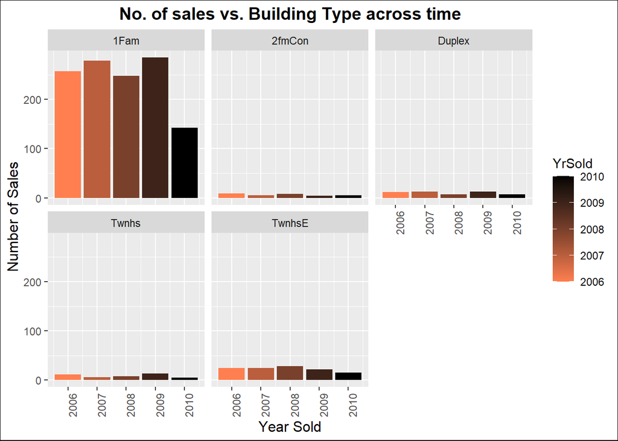

This graph depicts that most of the sales in all these years happened in Single Family detached apartments. The other building types show very less sale as compared to this one. The year 2010 bar is low because the data is incomplete for 2010.

## Further pre-processing

After a detailed analysis using EDA, we discover a few changes that need to be done, to prepare for modeling. For instance, Variable creation, Feature Engineering, cleaning test data etc. After performing EDA and visualizing so many plots, it was observed that out of all the variables whether original/ created, the following 15 features made an impact on Sale Price and Number of Sales.

```r
# Processed test and train data ------------------------------------------------

# Removing variables that are no longer required--------------------------------

new_train_data <- train_data[, c("Age", "TotalBsmtSF","BsmtQual", "BsmtExposure",
                                 "GarageArea", "GarageFinish", "OverallQual", "ExterQual",
                                 "KitchenQual", "FireplaceQu", "GrLivArea", "FullBath",
                                 "MSZoning", "Neighborhood" , "Foundation", "log_price",
                                 "SalePrice")]

new_test_data <- test_data[, c("Age", "TotalBsmtSF","BsmtQual", "BsmtExposure",
                               "GarageArea", "GarageFinish", "OverallQual", "ExterQual",
                               "KitchenQual", "FireplaceQu", "GrLivArea", "FullBath",
                               "MSZoning", "Neighborhood" , "Foundation", "log_price",
                               "SalePrice")]
```

## Modelling

Data modeling is essential for prediction of target variable. In modeling, we create a model based on all the variables that have been selected by EDA and pre-processing and that model helps to make further predictions in the data. There are various different modeling algorithms and the one that is implemented in this project is a Linear model. Linear model excepts the target variable to be normally distributed and as the Sale Price data was highly right skewed, we will be using the Log(Sale Price) as to lower down the skew impact.

#### **Problem 9 - Develop models to predict Sale Price based on the analysis performed in previous steps.**

Three models have have been build by combining various key features, *model_1*, *model_2*, *model_3*. The higher the Mean R squared value, the stronger is our model. The models and their summaries are as follows -

##### **Model 1 - Model 1 focuses to predict the Log Price of the variables using Quality variables and age of House.**

```r
# Model 1- Model build on the basis of Quality variables and Age----------------

model_1 <- lm(log_price ~ OverallQual + BsmtQual + ExterQual +
                KitchenQual + FireplaceQu + Age + BsmtExposure,
         new_train_data)

summary(model_1)
```

[output not shown]

##### **Model 2 - Model 2 focuses to predict the Log Price of the variables using area variables/ No. of rooms.**

In model no. 2, R square happens to be **0.7313** which means that **73.13%** of the Sale Price values can be explained by these area and size variables.

```r
# Model 2- Model build on top of Size and Area variables------------------------

model_2 <- lm(log_price ~ TotalBsmtSF + GarageArea + GrLivArea + FullBath ,
              new_train_data)

summary(model_2)
```

[output not shown]

##### **Model 3 - Model 3 focuses to predict the Log Price on top of the variables with high Correlation values.**

In model no. 3, R square is a high **0.8638** which means that **86.38 %** of the Sale Price values can be explained by the combination of *OverallQual* , *TotalBsmtSF* , *Age* , *Neighborhood* , *GrLivArea* , *GarageFinish* , *Foundation*.

```r
# Model 3- Model build on top of variables with high Correlation values---------

model_3 <- lm(log_price ~ OverallQual + TotalBsmtSF + Age +
                Neighborhood + GrLivArea + GarageFinish + Foundation,
              new_train_data)

summary(model_3)
```

```
##
## Call:
## lm(formula = log_price ~ OverallQual + TotalBsmtSF + Age + Neighborhood +
##     GrLivArea + GarageFinish + Foundation, data = new_train_data)
##
## Residuals:
##      Min       1Q   Median       3Q      Max
## -1.43198 -0.07087  0.00935  0.08603  0.46642
##
## Coefficients:
##                       Estimate Std. Error t value Pr(>|t|)
## (Intercept)          1.093e+01  5.394e-02 202.701  < 2e-16 ***
## OverallQual          8.479e-02  5.204e-03  16.293  < 2e-16 ***
## TotalBsmtSF          1.486e-04  1.318e-05  11.276  < 2e-16 ***
## Age                 -1.600e-03  3.332e-04  -4.801 1.75e-06 ***
## NeighborhoodBlueste -8.422e-02  1.127e-01  -0.747 0.455177
## NeighborhoodBrDale  -1.770e-01  5.494e-02  -3.222 0.001303 **
## NeighborhoodBrkSide  6.541e-02  4.661e-02   1.403 0.160717
## NeighborhoodClearCr  2.050e-01  4.814e-02   4.258 2.20e-05 ***
## NeighborhoodCollgCr  9.289e-02  3.910e-02   2.376 0.017656 *
## NeighborhoodCrawfor  2.333e-01  4.607e-02   5.065 4.62e-07 ***
## NeighborhoodEdwards  3.583e-03  4.255e-02   0.084 0.932890
## NeighborhoodGilbert  6.919e-02  4.067e-02   1.701 0.089132 .
## NeighborhoodIDOTRR  -1.256e-01  4.932e-02  -2.547 0.010963 *
## NeighborhoodMeadowV -1.245e-01  5.368e-02  -2.319 0.020518 *
## NeighborhoodMitchel  6.811e-02  4.353e-02   1.565 0.117913
## NeighborhoodNAmes    5.618e-02  4.115e-02   1.365 0.172364
## NeighborhoodNoRidge  1.580e-01  4.474e-02   3.531 0.000428 ***
## NeighborhoodNPkVill  2.443e-03  6.355e-02   0.038 0.969343
## NeighborhoodNridgHt  1.964e-01  4.095e-02   4.798 1.78e-06 ***
## NeighborhoodNWAmes   6.197e-02  4.273e-02   1.450 0.147258
## NeighborhoodOldTown -1.780e-02  4.557e-02  -0.391 0.696095
## NeighborhoodSawyer   6.295e-02  4.333e-02   1.453 0.146523
## NeighborhoodSawyerW  6.586e-02  4.248e-02   1.550 0.121319
## NeighborhoodSomerst  1.231e-01  4.054e-02   3.035 0.002446 **
## NeighborhoodStoneBr  2.024e-01  4.751e-02   4.261 2.17e-05 ***
## NeighborhoodSWISU    2.700e-02  5.269e-02   0.512 0.608440
## NeighborhoodTimber   1.421e-01  4.446e-02   3.196 0.001426 **
## NeighborhoodVeenker  2.450e-01  5.865e-02   4.178 3.12e-05 ***
## GrLivArea            2.683e-04  1.088e-05  24.655  < 2e-16 ***
## GarageFinishNone    -1.976e-01  2.213e-02  -8.927  < 2e-16 ***
## GarageFinishRFn     -2.652e-02  1.171e-02  -2.266 0.023624 *
## GarageFinishUnf     -6.360e-02  1.349e-02  -4.715 2.65e-06 ***
## FoundationCBlock     4.444e-02  1.784e-02   2.492 0.012833 *
## FoundationPConc      5.143e-02  2.038e-02   2.523 0.011731 *
## FoundationSlab      -4.039e-03  3.746e-02  -0.108 0.914154
## FoundationStone      5.684e-02  6.298e-02   0.903 0.366893
## FoundationWood      -6.247e-02  8.923e-02  -0.700 0.483969
## ---
## Signif. codes:  0 '***' 0.001 '**' 0.01 '*' 0.05 '.' 0.1 ' ' 1
##
## Residual standard error: 0.1493 on 1413 degrees of freedom
## Multiple R-squared:  0.8638, Adjusted R-squared:  0.8603
## F-statistic:   249 on 36 and 1413 DF,  p-value: < 2.2e-16
```

## Evaluation

Evaluation phase helps to select the best fit for our data. It involves re-modeling again and again to build an efficient model for predictions. In evaluation, the model is tested against RMSE (Root mean squared error) metric and using test data set. Following are the RMSE for three models in this project.

#### **Problem 10 - Evaluate the models created and select the fit that best predicts the sales price.**

```r
# Evaluation model 1 -----------------------------------------------------------

rmse(model_1, new_test_data)
```

```
## [1] 0.1942953
```

```r
# Evaluation model 2 -----------------------------------------------------------

rmse(model_2, new_test_data)
```

```
## [1] 0.2149376
```

```r
# Evaluation model 3 -----------------------------------------------------------

rmse(model_3, new_test_data)
```

```
## [1] 0.149457
```

##### **Analysis** -

It shows that **Model 3** is the best fit, as it has an RMSE of **0.149** which is least out of 3, and least the mean squared error, better is the fit of the equation. The predictors for this model are *OverallQual* , *TotalBsmtSF* , *Age* , *Neighborhood* , *GrLivArea* , *GarageFinish* , *Foundation*.

#### **Residual Plot for Model 3 with a cut off value of 0.75**

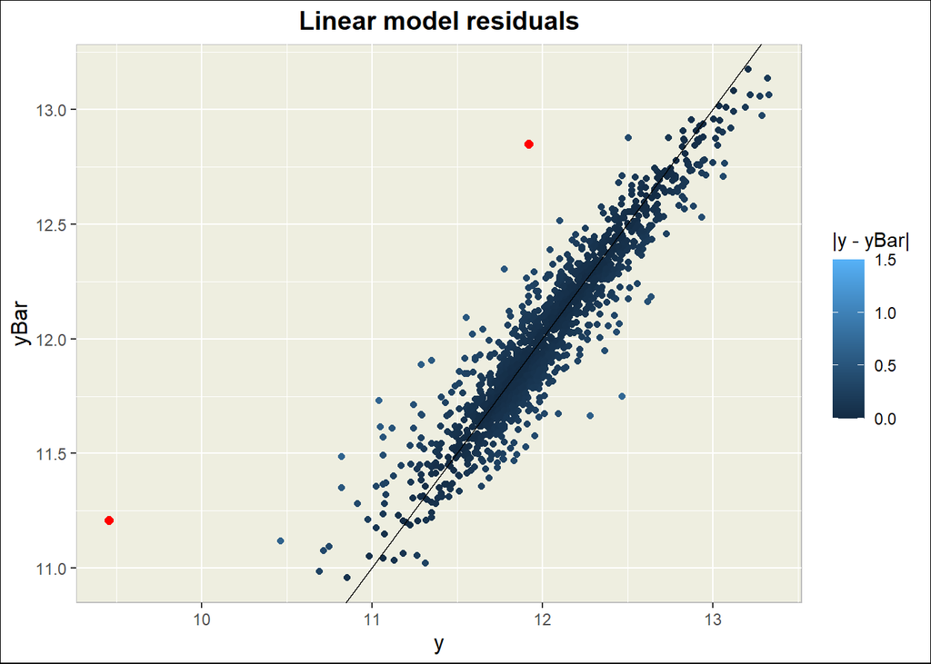

## Conclusion

Model 3 happened to be the best fit for predicting Sale Price as it has least RMSE. The model considered the following variables-

1. *OverallQual* - Overall material and finish Quality
2. *TotalBsmtSF* - Total square feet of Basement Area
3. *Age* - Age of the residential property
4. *Neighborhood* - Physical Location within Ames City Limits
5. *GrLivArea* - Above grade Living area
6. *GarageFinish* - Interior finish of the garage
7. *Foundation* - Type of foundation

According to the findings, **86.38 %** of the Sale Price values can be explained by the combination of these 7 features.

#### The following Key finding to be noted from this analysis -

1. Age of the property impacts the Sale price. The older the house gets, the more it loses it’s financial value.
2. Quality variables make a big impact on Sale price. The better the quality of the facilities, the higher the price gets.
3. Neighborhoods, Living Area, No. of Bathrooms happen to impact Sale Price and Number of Sales.
4. Detached Single Family apartments are the most common among residential sale property, whereas other building types fall very low on sales.
5. Seasonal trend observed in number of Sales. Summers observe almost more than double number of sales as compared to winters.
6. The final model has an RMSE of 0.149.

## References

1. https://nycdatascience.com/blog/student-works/machine-learning/machine-learning-project-ames-housing-dataset/
2. https://www.timeanddate.com/calendar/seasons.html?n=76